# Practical 3: ANCOVA (analysis of co-variance)

Dr. Jos Hageman  
Mathematical & Statistical Methods group – Biometris  
Wageningen University & Research

jos.hageman@wur.nl

### Packages

```r
# Get overview of all packages on your computer
pkgs <- rownames(installed.packages())

#if our package is missing, install it
if(!"ggplot2" %in% pkgs) install.packages("ggplot2")
if(!"car" %in% pkgs) install.packages("car")
if(!"doBy" %in% pkgs) install.packages("doBy")
if(!"multcomp" %in% pkgs) install.packages("multcomp")
```

## Exercises

### Exercise 1: Scientific writing

Three sets of teaching material on Scientific writing are compared. The three sets are developed by three programs in Wageningen: Animal Sciences, Food & Nutrition, and Plant Sciences. To test the material, volunteer students from different programs in the University were randomly assigned (CRD) to the three treatments. They all studied the material independently during 1 week in the summer holidays. Next the students took a test, for which they received a score (y, on 0-100 scale). They also indicated their exact age. The research question is whether there are any differences in expected (mean) score between the three teaching sets. Since it was anticipated that age might be influencing the scores, the scores were corrected for age by including age as a covariate in the analysis.

In the ANCOVA model for the observations *y*<sub>*i**j*</sub> we use an index i for set/program (i = 1, 2, 3), and an index j for student (j = 1, …, 12) within each set/program combination. The x-values also get indices ij as each student within a Program has his/her own age. The random terms *ϵ*<sub>*i**j*</sub> meet all the usual model assumptions. The model equation reads:

*y*<sub>*i**j*</sub> = *μ* + *τ*<sub>*i*</sub> + *β**x*<sub>*i**j*</sub> + *ϵ*<sub>*i**j*</sub>

We will start by reading in the data and creating a plot to visualize the data. In this plot, the regression lines are based on the observations per group; it is not a visualisation of the model defined above. Note that the plot is careful not to extrapolate the lines.

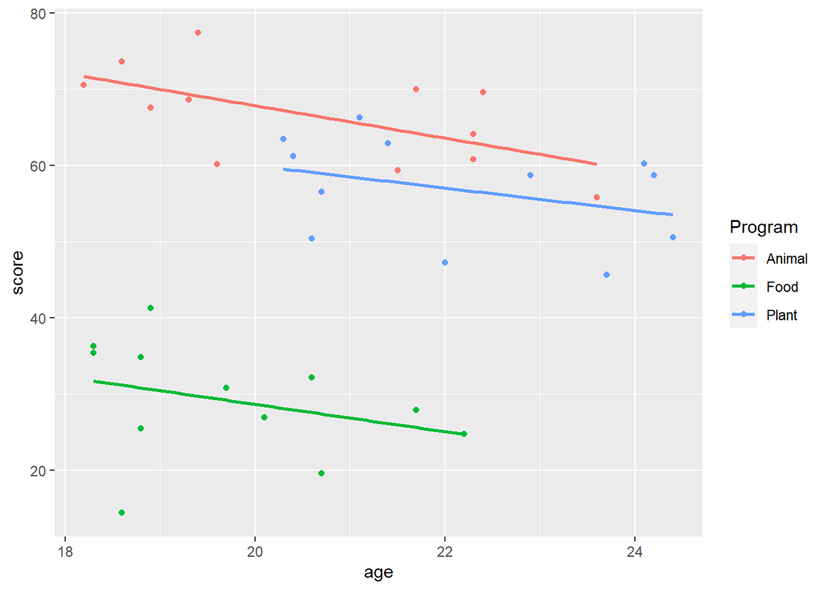

```r
# Read data into an object named teaching_data
# Check whether Program needs to be converted to a factor
teaching_data <- read.table(file = "Teaching material wur.txt", header=TRUE)
teaching_data$Program <- as.factor(teaching_data$Program)

# Visualise the data
# Create plot of score vs age
# and fit least squares regression per Program
library(ggplot2)

# define the plot, use geom_point to add the dots,
# use stats_smooth to add regression lines without standard errors
ggplot(data = teaching_data, aes(y=score,x=age,color=Program)) +
  geom_point()+
  stat_smooth(method="lm",se=FALSE)
```

1. What is meant by extrapolation?
1. Extrapolation means the extension of a graph (or model) beyond the range of measured predictor values assuming that existing trends will continue.

We did not expect the effects of age on score to be different for the different Programs, and we see in the graph that the three individual slopes (each based only on one samples) seem similar. Therefore, we choose a model forcing the three lines to have the same slope, but possibly with different intercepts (see introduction). Fit the model and get the output.

```r
# Create the ANCOVA model; note that lm (as always) decides
# on whether a variable or a covariate on whether it is coded as a factor
# or as a numerical variable

teaching.lm <- lm(score ~ Program +age, data=teaching_data)
summary(teaching.lm)
```

```
Call:
lm(formula = score ~ Program + age, data = teaching_data)

Residuals:
     Min       1Q   Median       3Q      Max
-16.8126  -3.5468   0.9212   4.5495  10.6338

Coefficients:
             Estimate Std. Error t value Pr(>|t|)
(Intercept)  104.2740    14.4434   7.219 3.36e-08 ***
ProgramFood  -38.9912     2.6902 -14.494 1.30e-15 ***
ProgramPlant  -6.8961     2.8121  -2.452   0.0198 *
age           -1.8305     0.6937  -2.639   0.0127 *
---
Signif. codes:  0 '***' 0.001 '**' 0.01 '*' 0.05 '.' 0.1 ' ' 1

Residual standard error: 6.399 on 32 degrees of freedom
Multiple R-squared:  0.8763,    Adjusted R-squared:  0.8647
F-statistic: 75.54 on 3 and 32 DF,  p-value: 1.31e-14
```

```r
library(car) #for type 2 sum of squares
Anova(teaching.lm)
```

```
Anova Table (Type II tests)

Response: score
          Sum Sq Df  F value    Pr(>F)
Program   8974.5  2 109.5723 4.826e-15 ***
age        285.2  1   6.9635   0.01274 *
Residuals 1310.5 32
---
Signif. codes:  0 '***' 0.001 '**' 0.01 '*' 0.05 '.' 0.1 ' ' 1
```

2. Give the equations of the three estimated lines, using the parameter estimates output.
3. The effect of age is not what we are primarily interested in, but it would be nice to know whether it was useful to include age as a covariate, so we will test whether, within Program, age is associated with expected (mean) test score (at *α* = 0.05). Give (1) *H*<sub>0</sub> in (a) model parameter(s) (2) outcome of test statistic, (3) p-value and (4) conclusion.
4. Now we know that correcting for age is useful, we want to test whether, for a given age, the teaching programs lead to different expected scores (alternative hypothesis). Give (1) *H*<sub>0</sub> in model parameters (2) outcome of test statistic, (3) p-value and (4) conclusion.
5. Suppose we could make a graph like the one at the top of this question at the population level assuming a common effect of age on mean score. What would you see in the graph when also *H*<sub>0</sub> of question 4 could not be rejected?
2. Program Animal: E(y) = 104.3 -1.831x = 104.3 – 1.831 x

   Program Food: E(y) = 104.3 + (-39.0) -1.831x = 65.3 – 1.831 x

   Program Plant: E(y) = 104.3 + (-6.9) -1.831x = 97.4 – 1.831 x
3. *H*<sub>0</sub>: *β* = 0 TS outcome t = -2.639 or F = 6.9635, p-value 0.01274 conclusion reject *H*<sub>0</sub>. It is shown at *α* = 0.05 that age significantly affect the test score (within Programs)
4. *H*<sub>0</sub> : *τ*<sub>1</sub> = *τ*<sub>2</sub> = *τ*<sub>3</sub>(=0) TS outcome F = 109.5723, p-value = 4.8*10-15 We reject H0. Conclusion: It is shown at *α* = 0.05 that at least two Programs differ in mean score when corrected for age / after adjustment for age.
5. Lines would be identical. The lines are already forced to be parallel by the model, but if in addition *H*<sub>0</sub> of no differences in intercept between Programs would be true, the lines would be identical.)

Before investigating which Programs differ in score, let us investigate first what the average age is per program and what is the mean age.

```r
#check out the average ages per group and the overall mean age
library(doBy)
summaryBy(age ~ Program, data = teaching_data, FUN=mean)
```

```
  Program age.mean
1  Animal   20.650
2    Food   19.725
3   Plant   22.150
```

```r
mean(teaching_data$age)
```

```
[1] 20.84167
```

In question 4 *H*<sub>0</sub> was rejected, so now we will investigate which Programs differ in score, corrected for age. We use emmeans() again. In addition to the specs-argument for the factor, we can specify the by-argument for the covariate. In ANCOVA estimated marginal means are also known as adjusted means. These are the observed means, adjusted for differences in average sample ages.

```r
## Post-hoc testing
library(emmeans)

emmeans(teaching.lm, specs = "Program", by = "age")
```

```
age = 20.8:
 Program emmean   SE df lower.CL upper.CL
 Animal    66.1 1.85 32     62.3     69.9
 Food      27.1 2.00 32     23.1     31.2
 Plant     59.2 2.06 32     55.0     63.4

Confidence level used: 0.95
```

7. At what age are the adjusted means computed?
8. Could we also compare the mean scores between programs at the three different mean ages *x̄*<sub>1</sub>, *x̄*<sub>2</sub>, and *x̄*<sub>3</sub>? Explain.
7. Age of comparison: 20.8 (see output emmeans()).
8. No we cannot compare marginal means for the three different programs if these means were calculated for each program at that program’s particular average x-value. The differences between the mean scores are comparable only if you compute them at the same age for each program because we have seen a significant effect of age.

Apply pairs() to the emmeans function and choose for no adjustment of p-values for multiple comparisons.

```r
pairs(emmeans(teaching.lm, specs = "Program", by = "age"), adjust="none")
```

```
age = 20.8:
 contrast       estimate   SE df t.ratio p.value
 Animal - Food      39.0 2.69 32  14.494  <.0001
 Animal - Plant      6.9 2.81 32   2.452  0.0198
 Food - Plant      -32.1 3.11 32 -10.329  <.0001
```

### Exercise 2: Rats and roasted peanuts

In a food experiment, rats receive a diet consisting of a mixture of roasted peanuts (fraction x) and normal peanuts (fraction 1 - x) to test whether roasting affects the peanuts’ nutritional value for rats. Six male and six female rats are randomly assigned to the x-values to be tested (separately for male and female rats), and the rats are further treated independently of each other. After the diet period the weight increase (y) is calculated for each rat. It is assumed that these observations are normally distributed with equal variances *σ*<sup>2</sup>. Due to unforeseen circumstances two male rats had to be withdrawn from the experiment.

The researchers are especially interested in the effect of the quantitative variable fraction. This variable is not measured before the experiment, but manipulated by the researchers. They are also interested in possible different reactions of male and female rats on the fraction of roasted peanuts, so in possible different slopes.

Software usually does not give estimated slopes and intercepts lines directly, but uses one group as a reference. Mean weight gain as a function of fraction and sex (see lectures) is modelled as:

*μ*<sub>*y*</sub> = *μ* + *τ*<sub>*i*</sub> + *β**x* + *λ*<sub>*i*</sub>*x* where i=1 (female), i=2 (male).

Splitting up by sex, this gives:

for females with *τ*<sub>1</sub> = 0, *λ*<sub>1</sub> = 0 (reference): *μ*<sub>*y*</sub> = *μ* + *τ*<sub>1</sub> + *β**x*

for males: *μ*<sub>*y*</sub> = *μ* + *τ*<sub>2</sub> + (*β*+*λ*<sub>2</sub>)*x*

In R coefficients output: (Intercept) refers to *μ*, sexM refers to *τ*<sub>2</sub>, fraction:sexM to *λ*<sub>2</sub>, etc. R numbers alphabetically, so Female (coded “F”) becomes 1 and Male (coded “M”) becomes 2. In R, the first group, so female, is the reference. Once parameter estimates are obtained, we can use these parameter estimates/coefficients to write the two estimated equations *ŷ* vs x (for males and for females).

First we read in the data and make a graph visualising the data: a graph based on the observations, not on the model.

```r
# Read data into an object named rats_data
rats_data <- read.table(file = "RoastedPeanuts.txt", header = TRUE)
str(rats_data)
```

```
'data.frame':   10 obs. of  3 variables:
 $ weight_gain: int  49 32 32 19 49 49 32 41 31 23
 $ fraction   : num  0 0.2 0.6 0.8 0 0.2 0.4 0.6 0.8 1
 $ sex        : chr  "M" "M" "M" "M" ...
```

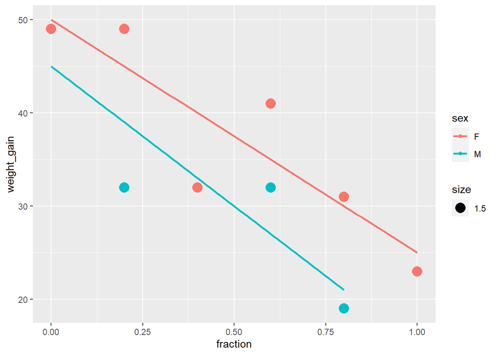

```r
# createa plot with least-quares fitted lines per sex
library(ggplot2)
ggplot(rats_data, aes(x = fraction, y = weight_gain, color = sex )) +
  geom_point(aes(size = 1.5)) +                # make the dots a little larger
  geom_smooth(method = "lm", se=FALSE)
```

Fit (estimate) the model allowing two lines with different intercept and different slopes. This means that we need an interaction between the fraction roasted peanuts and the sex of the rats. This is still a linear model, so use lm(). Use summary() to get the coefficients.

```r
# linear model
rats.lm1 <- lm(formula = weight_gain ~ fraction * sex, data = rats_data)
summary(rats.lm1)
```

```
Call:
lm(formula = weight_gain ~ fraction * sex, data = rats_data)

Residuals:
   Min     1Q Median     3Q    Max
    -8     -2      0      4      6

Coefficients:
              Estimate Std. Error t value Pr(>|t|)
(Intercept)     50.000      4.342  11.514 2.58e-05 ***
fraction       -25.000      7.171  -3.486    0.013 *
sexM            -5.000      6.501  -0.769    0.471
fraction:sexM   -5.000     11.892  -0.420    0.689
---
Signif. codes:  0 '***' 0.001 '**' 0.01 '*' 0.05 '.' 0.1 ' ' 1

Residual standard error: 6 on 6 degrees of freedom
Multiple R-squared:  0.7966,    Adjusted R-squared:  0.6949
F-statistic: 7.834 on 3 and 6 DF,  p-value: 0.01693
```

1. Give the estimated value of all parameters in the model, i.e. estimates for *μ*, *τ*<sub>1</sub>, *τ*<sub>2</sub>, *β*, *λ*<sub>1</sub> and *λ*<sub>2</sub>.
2. The parameter estimates can be combined to describe the lines we see in the graph (because of the interaction, the observation-based lines and the model-based lines are the same). Give the equations of the two estimated lines.
1. *μ* = 50 (*r**e**f**e**r**e**n**c**e*)

   *τ*<sub>1</sub> = 0.0 (*f**e**m**a**l**e**s*)

   *τ*<sub>2</sub> = − 5.0 (*m**a**l**e**s*)

   *β* = − 25.0 (*c**o**m**m**o**n**s**l**o**p**e*)

   *λ*<sub>1</sub> = 0.0 (*f**e**m**a**l**e**s*)

   *λ*<sub>2</sub> = − 5.0 (*m**a**l**e**s*)
2. males E(y) = 50.0 – 5.0 + ( -25.0 -5.0) * x = 45.0 – 30.0*x

   females E(y) = 50.0 + -25.0 * x

Get the ANOVA-table of the model in Anova() from the cars package. In the ANOVA table we see 3 F-tests.

```r
library(car) #for type 2 sum of squares
Anova(rats.lm1)
```

```
Anova Table (Type II tests)

Response: weight_gain
             Sum Sq Df F value   Pr(>F)
fraction     791.14  1 21.9760 0.003368 **
sex          121.15  1  3.3651 0.116272
fraction:sex   6.36  1  0.1768 0.688808
Residuals    216.00  6
---
Signif. codes:  0 '***' 0.001 '**' 0.01 '*' 0.05 '.' 0.1 ' ' 1
```

3. What are the three hypotheses that are tested by these F-tests?
4. To test if the two lines have different slopes: Write down (1) definition of the test statistic, (2) its null distribution, (3) outcome and (4) p-value.
5. We investigate if the sex of the rats has influence on the response. *H*<sub>0</sub>: sex has no effect. (*H*<sub>*a*</sub>: *H*<sub>0</sub> is false.) The null hypothesis (male and female have same intercept and same slope), stated in terms of the parameters of the model given in the introduction is *H*<sub>0</sub>: *τ*<sub>1</sub> = *τ*<sub>2</sub>(=0) AND *λ*<sub>1</sub> = *λ*<sub>2</sub>(=0). If this null hypothesis is true, at the population level: the two lines have the same intercept / are parallel / are identical / are horizontal. (choose one of these options and explain).
3. *H*<sub>0</sub> (1) *f**r**a**c**t**i**o**n* : *β* = 0

   *H*<sub>0</sub> (2) *s**e**x* : *τ*<sub>2</sub> = 0 (*τ*<sub>1</sub>=0 *b**y* *d**e**f**i**n**i**t**i**o**n*)

   *H*<sub>0</sub> (3) *f**r**a**c**t**i**o**n* : *s**e**x* : *λ*<sub>2</sub> = 0 (*l**a**m**b**d**a*<sub>1</sub>=0 *b**y* *d**e**f**i**n**i**t**i**o**n*)
4. TS (definition) F=MS(fraction:sex)/MS(Residuals), Null-distribution F with df1= 1, df2=6 outcome TS 0.1768, P-value 0.688
5. Are identical: no different lines for males and females, so have same intercept AND same slope. Not horizontal, because effect of x still there = slope is not 0.

To perform the test in question 5, we need to run a reduced model obtained by setting *τ*<sub>1</sub> = *τ*<sub>2</sub>(=0), and *λ*<sub>1</sub> = *λ*<sub>2</sub>(=0).

```r
# reduced model
rats_reduced.lm <- lm(weight_gain ~ fraction, data = rats_data)
summary(rats_reduced.lm)
```

```
Call:
lm(formula = weight_gain ~ fraction, data = rats_data)

Residuals:
    Min      1Q  Median      3Q     Max
-10.274  -3.953   1.311   3.340   8.840

Coefficients:
            Estimate Std. Error t value Pr(>|t|)
(Intercept)   47.331      3.518  13.453 8.93e-07 ***
fraction     -25.285      6.181  -4.091  0.00348 **
---
Signif. codes:  0 '***' 0.001 '**' 0.01 '*' 0.05 '.' 0.1 ' ' 1

Residual standard error: 6.553 on 8 degrees of freedom
Multiple R-squared:  0.6766,    Adjusted R-squared:  0.6361
F-statistic: 16.74 on 1 and 8 DF,  p-value: 0.003481
```

```r
Anova(rats_reduced.lm)
```

```
Anova Table (Type II tests)

Response: weight_gain
          Sum Sq Df F value   Pr(>F)
fraction  718.59  1  16.735 0.003481 **
Residuals 343.51  8
---
Signif. codes:  0 '***' 0.001 '**' 0.01 '*' 0.05 '.' 0.1 ' ' 1
```

6. What is the *H*<sub>0</sub> for the F-test in the summary() output?
7. Write down SSE, MSE and dfE for the full model (output see above) and SSE, MSE and dfE for the reduced model (question 4).
6. *H*<sub>0</sub> : *β* = 0. The equation of the model we use is *μ*<sub>*y*</sub> = *μ* + *β*<sub>*x*</sub>. The F test in summary() in general tests whether the model has predictive value (better than simply the average of the response). As we now have a model with only one slope, the F-test is tests whether that slope is zero.
7. Full model: SSE 216.00, MSE 36.00, dfE 6

   Reduced model: SSE 343.51, MSE 42.94, dfE 8

We will check if there is a significant difference between the two models (a full and a reduced one) using anova(model1, model2).

```r
# compare the models with an F-test
anova(rats_reduced.lm, rats.lm1)
```

```
Analysis of Variance Table

Model 1: weight_gain ~ fraction
Model 2: weight_gain ~ fraction * sex
  Res.Df    RSS Df Sum of Sq     F Pr(>F)
1      8 343.51
2      6 216.00  2    127.51 1.771 0.2486
```

8. What is the outcome for the F statistic and the P-value for the comparison of the two models?
9. What is your conclusion?
8. F = 1.771 with a p-value of 0.2486.
9. Conclude (at *α* = 0.05) that there is no effect of sex on how mean weight gain changes with the fraction roasted peanuts. OR conclude that sex does not improve the prediction of mean weight gain when x is already in the model.